# Krishnan_Lu_320_Final_Project

Rahul Krishnan, Thomas Lu

5/13/2020

Hello, and welcome to our data science tutorial! Here you’ll learn more than you ever thought you’d know about data science–how to ingest it programmatically, how to clean it into a usable format, and most importantly, how to analyze it so it actually means something to most people!

We’ve chosen to use [this Kaggle dataset](https://www.kaggle.com/rounakbanik/pokemon?select=pokemon.csv) about Pokemon. Specifically, it contains an encyclopedic repository on all 801 (as of May 14, 2020) pokemon in existence; stats, type, birth info, vital statistics, legendary status, and much, much more.

We felt it prudent to use a dataset that reminded us of childhood so as to ease the reader into what is considered a very complex field. We also felt this dataset, with its wealth of variables, was ripe for analysis and study. So without further ado, let’s get this show on the road–on the road to Viridian City!

Shut up, I thought it was funny.

We start below by loading the data. The first step of that first step is to import two R libraries: *dplyr* and *tidyverse*. These import several functions from R that will enable us to run statistical analysis on large datasets without needing to do every single one by hand like savages.

```r
library(dplyr)
library(tidyverse)
library(broom)
```

The second step is loading the data from the CSV (courtesy of Kaggle) into a data frame. A data frame is basically a data table (rows and columns, nothing more) stored in a data structure that R and other programming languages can easily read and operate on.

We’ll also change the data type of the generation column so that it’s easier to work with for future analysis.

```r
pokemon_df <- read.csv("E:/1 WORK/CMSC320/Final Project/pokemon.csv")
pokemon_df$generation <- as.character(pokemon_df$generation)
head(pokemon_df)
```

```
##                     abilities against_bug against_dark against_dragon
## 1 ['Overgrow', 'Chlorophyll']        1.00            1              1
## 2 ['Overgrow', 'Chlorophyll']        1.00            1              1
## 3 ['Overgrow', 'Chlorophyll']        1.00            1              1
## 4    ['Blaze', 'Solar Power']        0.50            1              1
## 5    ['Blaze', 'Solar Power']        0.50            1              1
## 6    ['Blaze', 'Solar Power']        0.25            1              1
##   against_electric against_fairy against_fight against_fire against_flying
## 1              0.5           0.5           0.5          2.0              2
## 2              0.5           0.5           0.5          2.0              2
## 3              0.5           0.5           0.5          2.0              2
## 4              1.0           0.5           1.0          0.5              1
## 5              1.0           0.5           1.0          0.5              1
## 6              2.0           0.5           0.5          0.5              1
##   against_ghost against_grass against_ground against_ice against_normal
```

[output cut: 41 more lines]

Yes, really. That’s all there is to loading the data! But we’re not done yet, sorry to say. We next have to tidy the data.

You’ll notice that there are a few columns that R and Excel can’t read well (i.e. the Japanese name), and others that Americans can’t read well (metric units). What we’ll do next is delete the former column, and rename a few others to be more meaningful.

Actually, let’s delete the American name as well. It may be a bit more aesthetically pleasing, but it won’t be useful in our analysis. This is an important part of data science; sometimes we sacrifice the look of our table for that which will help us mathematically.

```r
tidy_pokemon <- pokemon_df[-c(1,25,30,33,31)]
head(tidy_pokemon)
```

```
##   against_bug against_dark against_dragon against_electric against_fairy
## 1        1.00            1              1              0.5           0.5
## 2        1.00            1              1              0.5           0.5
## 3        1.00            1              1              0.5           0.5
## 4        0.50            1              1              1.0           0.5
## 5        0.50            1              1              1.0           0.5
## 6        0.25            1              1              2.0           0.5
##   against_fight against_fire against_flying against_ghost against_grass
## 1           0.5          2.0              2             1          0.25
## 2           0.5          2.0              2             1          0.25
## 3           0.5          2.0              2             1          0.25
## 4           1.0          0.5              1             1          0.50
## 5           1.0          0.5              1             1          0.50
## 6           0.5          0.5              1             1          0.25
##   against_ground against_ice against_normal against_poison against_psychic
```

[output cut: 27 more lines]

Dataset has been tidied, for the most part. Now for the analysis.

Example: Distribution of Pokemon Typings

What we first want to do is rewrite the types to be characters, so that we can present them more cleanly. We also want to rename them to be more verbose; you should always do this whenever possible, assuming of course that you don’t compromise any meaningful data.

```r
type_as_character <- pokemon_df[,c("type1","type2")]
type_as_character[] <- lapply(type_as_character, as.character)

types <- c("normal","fire","water","grass","electric","psychic","ice","dragon",
           "dark","fairy","fighting","flying","poison","ground","rock","bug","ghost","steel")
typings <- data.frame(types)
typings[] <- lapply(typings, as.character)
typings$numType <- 0
```

That was just making the table look pretty. Next up comes the actual math (yeah, I know, icky). Bear with me, it’s actually not bad. You might be surprised at how intuitive you find it!

What we do here is iterate over the typings column and count how many of each type there are. We then calculate a *type percentage* the way you calculate any percentage; by dividing by a total count (in this case, the number of total pokemon) and multiplying the result by 100.

```r
for (i in 1:nrow(typings)) {
  n1 = str_count(type_as_character[1],pattern = typings$types[i])
  n2 = str_count(type_as_character[2],pattern = typings$types[i])
  typings$numType[i] <- n1 + n2
}
typings$percent_type <- typings$numType/801 * 100
```

So we have the percentages of each type. That’s great! It’s also useless!

Here’s the thing. In data science, you can have the most brilliant, revolutionary insight ever made. Unfortunately, if you can’t present it in a way people can easily interpret, it was all for nothing.

Fortunately, we can deal with that problem by way of a *plot*. In a plot, we present the data as a picture. Pictures instinctively appeal to humans more than a dry list of numbers; that’s what makes us human and not robots, after all.

I’m sure you all remember learning about graphing data in middle school, but now we can do it programmatically using real data science. The following plot uses the list of types as the independent variable, and the percentage of each type as the dependent variable. We fiddle a little with the axis of the labels, write our title, and present away!

Pop quiz: What can we interpret from this plot?

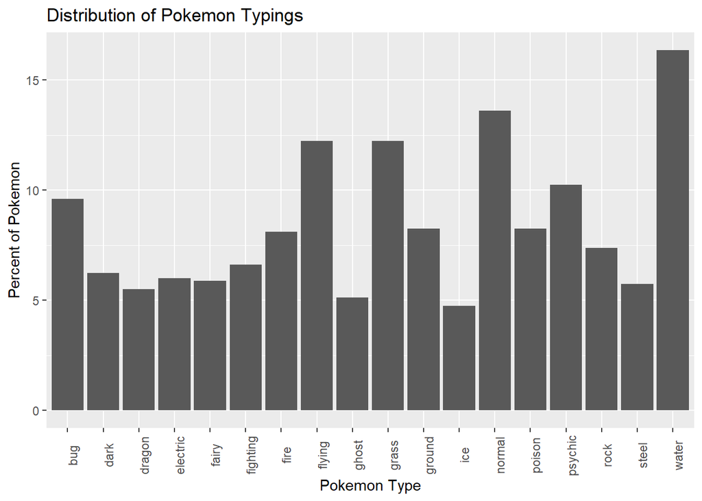

```r
ggplot(typings,aes(x=types, y=percent_type)) +
  geom_bar(stat="identity") +
  theme(axis.text.x = element_text(angle = 90)) +
  labs(x = "Pokemon Type",
       y = "Percent of Pokemon") +
  ggtitle("Distribution of Pokemon Typings")
```

If you guessed that water is the most common type, followed by normal, you win!

I don’t know *what* you win, but whatever. I’ll figure it out later.

Here’s a hypothesis for you. In RPG’s, the typical trend is that units that can withstand more damage are typically slower, in order to compensate for such strengths. It follows that Pokemon will be no exception.

Well? Is it?

Let’s find out.

We start by filtering out a few extreme outliers. In this case, we don’t want anyone whose scaled defenses end up being 0, because that tells us nothing meaningful.

Oh, I almost forgot, I need to define scaled defenses! The idea is that stats can vary quite wildly depending on the pokemon. Some have very balanced stats overall, and others have just a few very high stats with everything else being very low. We want to standardize these stats. That is to say, we only care about *relative* stats.

As an example, one pokemon might have very high defense, but it’s not such a meaningful stat if all of its stats are so high. How would we accurately measure that pokemon’s relationship between defense and speed then, unless we standardized these stats?

We do this for all defensive stats (i.e. defense, special defense, hp) and speed.

We then plot the data using scaled defenses as the independent variable, and scaled speed as the dependent variable. Did we reach the expected conclusion?

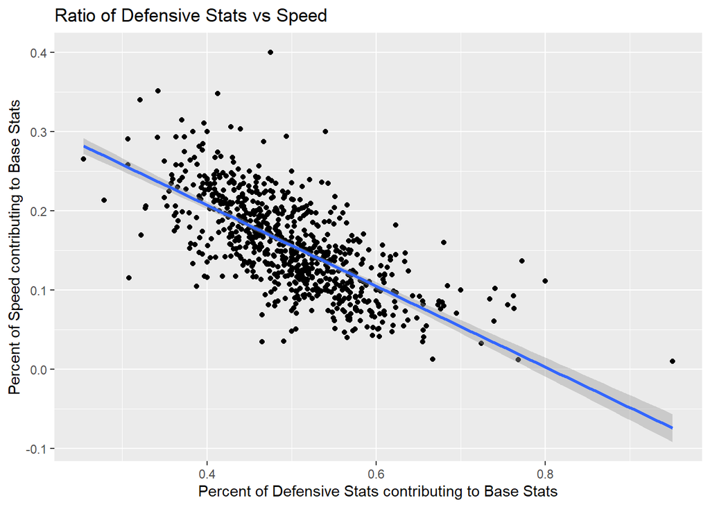

```r
pokemon_df %>%
  filter((defense + sp_defense + hp)/base_total > 0) %>%
  mutate(scaled_defenses = (defense + sp_defense + hp)/base_total) %>%
  mutate(scaled_speed = speed/base_total) %>%

  ggplot(aes(x = scaled_defenses, y = scaled_speed)) +
  geom_point() +
  geom_smooth(method=lm) +
  labs(x = "Percent of Defensive Stats contributing to Base Stats",
       y = "Percent of Speed contributing to Base Stats") +
  ggtitle("Ratio of Defensive Stats vs Speed")
```

Yes, we did! We’ve proven the existence of a strong, negative, linear relationship between scaled defenses and scaled speed of a pokemon. That is to say, all else being equal, pokemon with lower relative defenses tend to be faster.

What else can we graphically analyze?

Here’s a start. It’s a popular fan theory (especially among die-hard traditionalists, or “genwunners” as they’re not-so-affectionately called) that there’s been power creep over the generations. Essentially, many people believe that pokemon introduced in later generations are stronger than those introduced in early generations.

Are they?

Good question. Let’s find out.

What we have here is a violin plot. It’s used to illustrate the overall distributions of BST stats vs Pokemon Generations.

The first thing we do is group by generation. That means after that line, all calculations will be done on entire groups of generations, not on the dataset as a whole.

Next, we factor generation. That means we separate it into bins of a certain width, which allows us to see the distribution by generation more clearly.

Then we invoke the violin plot, and voila!

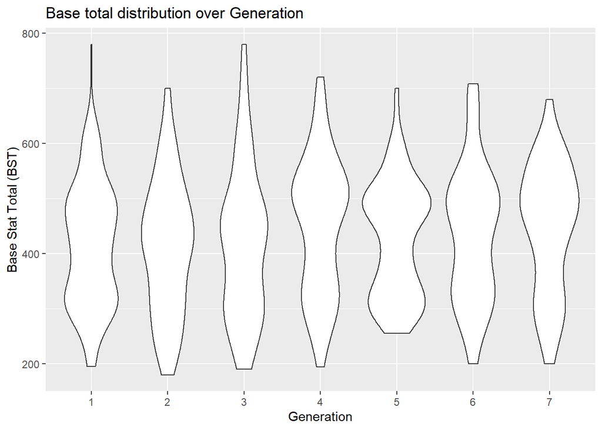

```r
pokemon_df %>%
  group_by(generation) %>%
  ggplot(aes(x=factor(generation), y = base_total)) +
  geom_violin() +
  labs(title = "Base total distribution over Generation",
               x = "Generation",
               y = "Base Stat Total (BST)")
```

As we can see, base stat total doesn’t go up with generation. Nor does it go down, interestingly enough. It seems to oscillate; sometimes being high, sometimes low. Sometimes it’s even bimodal, and sometimes not.

That’s another lesson to be learned in data science. Sometimes conclusions are unclear. In any case, you’ll need to learn to make do with what you have and figure out where you might improve in the future.

Next up is the machine learning part. Sounds scary, I know. Rest assured, we’re not implementing SkyNet or anything. The idea is that we’re going to use statistical algorithms to try and classify certain pokemon based on their statistics. In this case, what we’re trying to see is if there’s any significant factors between a pokemon’s stats, and what generation they could plausibly come from. With this tree, we’ll be specifically testing the relations between a Pokemon’s Generation, their several of their in-game stats like attack, defense, and their weight. Just to have a bit of fun, we’ll also see if we can find any relations using their base egg steps, and their sex distribution as well.

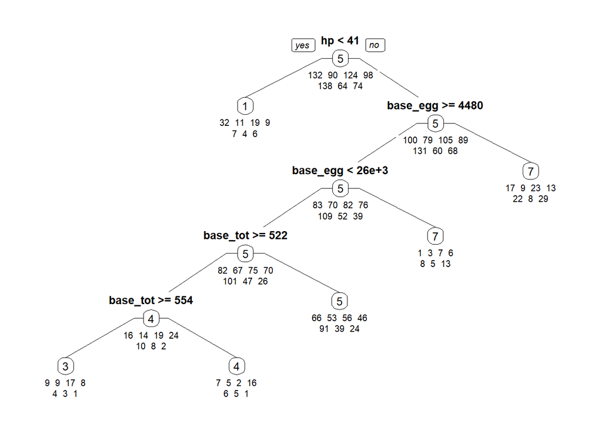

```r
library(rpart)
library(rpart.plot)
set.seed(123)
index<-sample(1:nrow(pokemon_df), .90*nrow(pokemon_df), replace=F)

classifiedData <- tidy_pokemon %>%
  subset(select=c("attack","base_egg_steps","base_total"
                  ,"defense","height_m","hp"
                  ,"percentage_male","sp_attack","sp_defense"
                  ,"speed","weight_kg","generation"))

traindata<-classifiedData[index,]
validdata<-classifiedData[-index,]

ct<-rpart(generation~., data=traindata, method="class", cp=0, minsplit=4,xval=6)
pruned_ct<-prune(ct, cp=ct$cptable[which.min(ct$cptable[,'xerror']),'CP'])
prp(pruned_ct, type=1, extra=1, under=TRUE)
```

Reading this graph is relatively simple. The blurb at the top, such as hp < 41, is simply an expression, and you simply go left or right based on a pokemon’s traits, until you reach a leaf. Each leaf represents a plausible generation that this pokemon could have come from. For example, if you had a Pokemon that had an hp > 41, but a base egg steps of less than 4480, then according to our model, its likely that this Pokemon hails from the Alola region, Generation 7!

Let’s try a few more plots. Here, we want to test if male pokemon are generally heavier than their female counterparts. Fortunately, we have a variable called *percentage_male.* We regress weight in kg on that variable.

Something to remember before we do that is the existence of a few outliers. Some pokemon have no gender, in which case they would hinder this analysis. That’s why we remove them, as well as anyone without a listed weight.

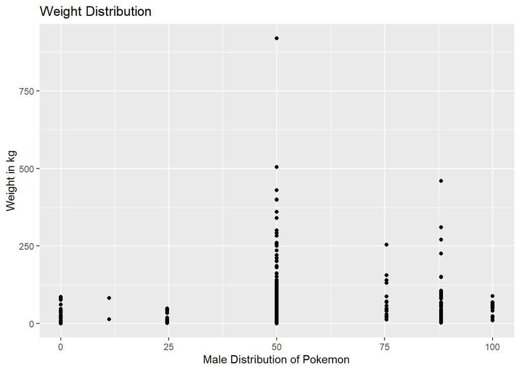

```r
weight_differences <- pokemon_df %>%
  filter(!is.na(percentage_male)) %>%
  filter(!is.na(weight_kg)) %>%
  ggplot(mapping=aes(x=percentage_male, y=weight_kg)) +
  geom_point() +
  labs(x = "Male Distribution of Pokemon",
       y = "Weight in kg") +
  ggtitle("Weight Distribution")

weight_differences
```

As we can see, male-majority pokemon tend to be *slightly* heavier than their female majority counterparts, but not by much. The heaviest appear to be those evenly split between male and female.

Here’s another question I’d like answered: we know if males tend to be *heavier* than females, but do they also tend to be taller?

The procedure is essentially the same as above, with height taking place of weight.

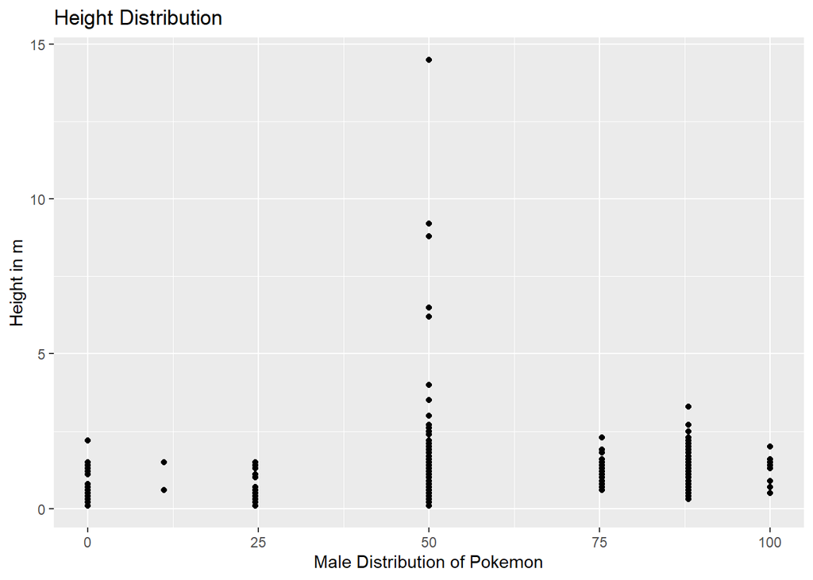

```r
height_differences <- pokemon_df %>%
  filter(!is.na(percentage_male)) %>%
  filter(!is.na(height_m)) %>%
  ggplot(mapping=aes(x=percentage_male, y=height_m)) +
  geom_point() +
  labs(x = "Male Distribution of Pokemon",
       y = "Height in m") +
  ggtitle("Height Distribution")

height_differences
```

Another thing that can be observed is that “Classification” of a Pokemon seems to have gotten more complex and lengthy over time. Charizard, the Generation 1 fire starter, is simply called the Flame Pokemon. However, Gible, the starting form of Generation 4’s fearsome Garchomp, is called the Land Shark Pokemon. Can we show that names have been getting longer, however?

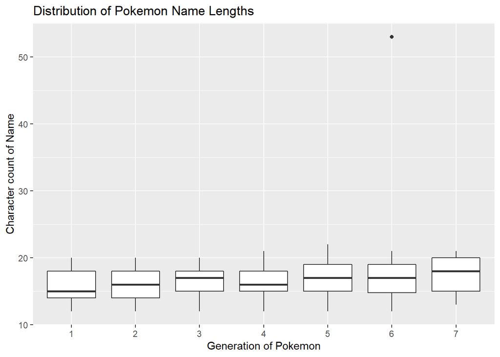

```r
pokemon_df$classfication <- as.character(pokemon_df$classfication)


pokemon_df %>%
  mutate(Classification_Length = nchar(classfication)) %>%
  group_by(generation) %>%
  ggplot(mapping=aes(x = generation, y = Classification_Length)) +
  geom_boxplot() +
  labs(x = "Generation of Pokemon",
       y = "Character count of Name") +
  ggtitle("Distribution of Pokemon Name Lengths")
```

To test this, let’s try a linear regression, one of our other machine learning methods, to gain some insights. Unlike the regression tree, however, this process is much less involved. We’ll be performing this regression on the height of a pokemon, against their defensive stats: hp, defense, and special defense.

Here, we see what effect defenses have on height; are more defensive pokemon taller?

In order to have a proper hypothesis test, we first need to establish a null hypothesis: that none of these stats have any effect on height. We next need to establish an alpha level; that is, a maximal probability value *alpha* such that any p-value above alpha is treated as statistically insignificant. We will choose alpha=0.05, purely because it’s a common alpha level.

```r
  height_reg <- lm(height_m~defense + sp_defense + hp, data=tidy_pokemon)
  height_reg
```

```
##
## Call:
## lm(formula = height_m ~ defense + sp_defense + hp, data = tidy_pokemon)
##
## Coefficients:
## (Intercept)      defense   sp_defense           hp
##   -0.721245     0.008262     0.002182     0.016299
```

Use p-value to say which things are relevant and which ones aren’t. SP_defense has high p value (i.e. over 0.05), so we conclude that its not statistically significant to this regression. In contrast, the p-values for defense and hp are so low R has to round them down to 0. With that in mind, it is safe to say that defense and hp have statistically significant effects on pokemon height. Ergo, we reject the null hypothesis.

```r
height_reg_stats <- height_reg %>%
  tidy()
height_reg_stats %>% knitr::kable()
```

| term | estimate | std.error | statistic | p.value |
| --- | --- | --- | --- | --- |
| (Intercept) | -0.7212452 | 0.1120584 | -6.436333 | 0.0000000 |
| defense | 0.0082616 | 0.0012537 | 6.589853 | 0.0000000 |
| sp_defense | 0.0021823 | 0.0014360 | 1.519640 | 0.1290084 |
| hp | 0.0162988 | 0.0013122 | 12.420922 | 0.0000000 |

Now, how about a Pokemon’s defensive stats vs their weight? Let’s try another linear regression, but with weight_kg as our response variable instead.

Our alpha level is once again 0.05, and our null hypothesis is that none of the aforementioned defensive stats have any effet (in this case, on weight).

```r
weight_reg <- lm(weight_kg~defense + sp_defense + hp, data=tidy_pokemon)
  weight_reg
```

```
##
## Call:
## lm(formula = weight_kg ~ defense + sp_defense + hp, data = tidy_pokemon)
##
## Coefficients:
## (Intercept)      defense   sp_defense           hp
##  -125.15972      1.21702     -0.01209      1.42521
```

SP_defense shown itself to not necessarily be correlated with height and weight. The other variables have, however.

```r
weight_reg_stats <- weight_reg %>%
  tidy()
weight_reg_stats %>% knitr::kable()
```

[output not shown]

In both regressions, sp_defense was shown to be largely irrelevant to the size metrics of a pokemon.

This bit of code needs the code from the overall type distribution to be here as well.

We also want to see which are the most common dual types.

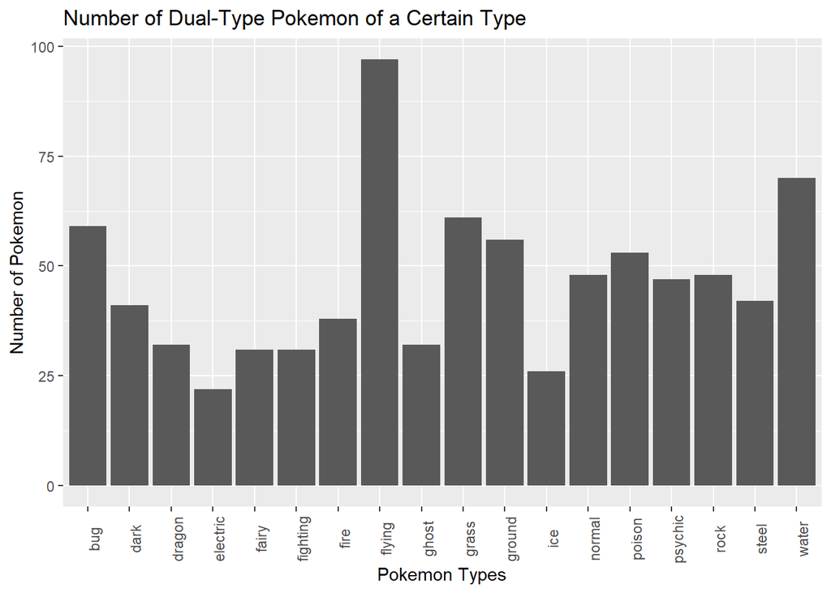

```r
dual_types <- type_as_character %>%
  filter(type2 != "")

types <- c("normal","fire","water","grass","electric","psychic","ice","dragon",
           "dark","fairy","fighting","flying","poison","ground","rock","bug","ghost","steel")
dual_typings <- data.frame(types)
dual_typings[] <- lapply(typings, as.character)
dual_typings$numType <- 0


for (i in 1:nrow(dual_typings)) {
  n1 = str_count(dual_types[1],pattern = dual_typings$types[i])
  n2 = str_count(dual_types[2],pattern = dual_typings$types[i])
  dual_typings$numType[i] <- n1 + n2
}

ggplot(dual_typings,aes(x=types, y=numType)) +
  geom_bar(stat="identity") +
  theme(axis.text.x = element_text(angle = 90)) +
  labs(x = "Pokemon Types",
       y = "Number of Pokemon") +
  ggtitle("Number of Dual-Type Pokemon of a Certain Type")
```

Minior was causing too many problems, since it had 2 different capture rates. We’ll be removing it now. Stupid Outlier.

Now that we’re rid of that troublesome monster that shall not be named, we’ve come to our final plot. Yes, we’re already at the end. It may not have hit you yet how much you’ve learned, but trust yourself; you have.

We now wish to see how base stat total affects capture rate. By now, you should be experts at linear regression, so you can tell how the column data is first formatted for ease of calculations before the independent and dependent variables are plugged into ggplot. Lastly, the graph shows us a negative, almost logistical relationship between base stat total and capture rate. That is to say, the higher the base stat total, the lower the capture rate. This is to be expected; after all, strong pokemon tend to resist being captured more, implying a lower capture rate.

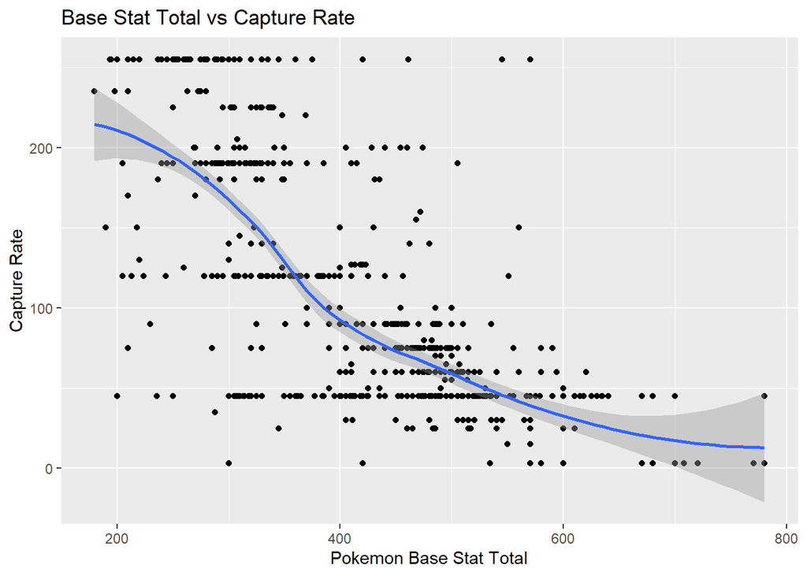

```r
bstvcapture_df <- pokemon_df[-c(774),]
bstvcapture_df$capture_rate <- as.character(bstvcapture_df$capture_rate)
bstvcapture_df$capture_rate <- as.numeric(bstvcapture_df$capture_rate)
ggplot(data=bstvcapture_df,mapping=aes(x=base_total,y=capture_rate)) +
  geom_point() +
  geom_smooth()+
  labs(x = "Pokemon Base Stat Total",
       y = "Capture Rate") +
  ggtitle("Base Stat Total vs Capture Rate")
```

Now our journey has come to an end. Congratulations! When you begin your work as a data scientist, you will be astounded at just how much you know. You will be able to perceive the world and solve problems in a completely new way. Your workplace, your lifestyle, and to some extent, your paycheck will thank you greatly.

I hope you enjoyed this tutorial. Feel free to refer back any time you have a question. In the meantime, good-bye until we meet again.